# GeospatialStroke

Repository of contributions for Frontiers in Neurology-Stroke journal, focussing on geospatial analysis and transport.

## osmdata for Monash Medical Centre

A long-handed way to get the MMC polygon directly from Open Street Map (because geocoding will only return a point)

```r
library (osmdata)
```

```
## Data (c) OpenStreetMap contributors, ODbL 1.0. http://www.openstreetmap.org/copyright
```

```r
amen <- opq ("Clayton Victoria") %>%
    add_osm_feature (key = "amenity", value = "hospital") %>%
    osmdata_sf () %>%
    magrittr::extract2 ("osm_polygons")
mmc <- amen$geometry [grep ("Monash Medical Centre", amen$name)]
```

Most `dodgr` functions work with simple WGS-84-projected values, rather than `sf` objects, so the MMC can be converted to a numeric centroid here:

```r
mmc <- as.numeric (sf::st_centroid (mmc [[1]]))
```

## Distance chloropleth

Extracting the surrounding street network can then be done very simply with the [`dodgr` package](https://github.com/ATFutures/dodgr). The `expand` argument is a relative expansion, so the value of `expand = 1` will **double** the size of the bounding box. (And there is currently no way to do this in absolute terms, although that would be a nifty enhancement.)

```r
library (dodgr)
#devtools::load_all ("../../atfutures/dodgr", export_all = FALSE)
dat <- dodgr_streetnet ("Clayton Victoria", expand = 1)
```

Then extract distances between the MMC centroid and all points of the surrounding network. The `dodgr_contract_graph()` function contracts the street network to junction nodes only, which makes these kinds of calculations much faster.

```r
graph <- weight_streetnet (dat, wt_profile = "motorcar")
nrow (graph)
```

```
## [1] 105185
```

```r
graph <- dodgr_contract_graph (graph)$graph
nrow (graph)
```

```
## [1] 62987
```

```r
verts <- dodgr_vertices (graph)
d <- dodgr_dists (graph = graph, from = mmc, to = verts)
```

```r
indx <- cbind (match (graph$from_id, colnames (d)),
               match (graph$to_id, colnames (d)))
indx <- apply (indx, 1, function (i) min (i, na.rm = TRUE))
graph$dmmc <- d [indx]
```

## Visualistion

Visualising first requires conversion back to `sf` format:

```r
graph_sfc <- dodgr_to_sfc (graph)
library (sf)
graph_sf <- st_sf (graph_sfc$dat, graph_sfc$geoms)
# not all nodes will necessarily be reachable on the network, so remove
# unreachable ones
graph_sf <- graph_sf [which (!is.na (graph_sf$dmmc)), ]
```

Then use `mapview` for a simple interactive visualisation (with screenshot below).

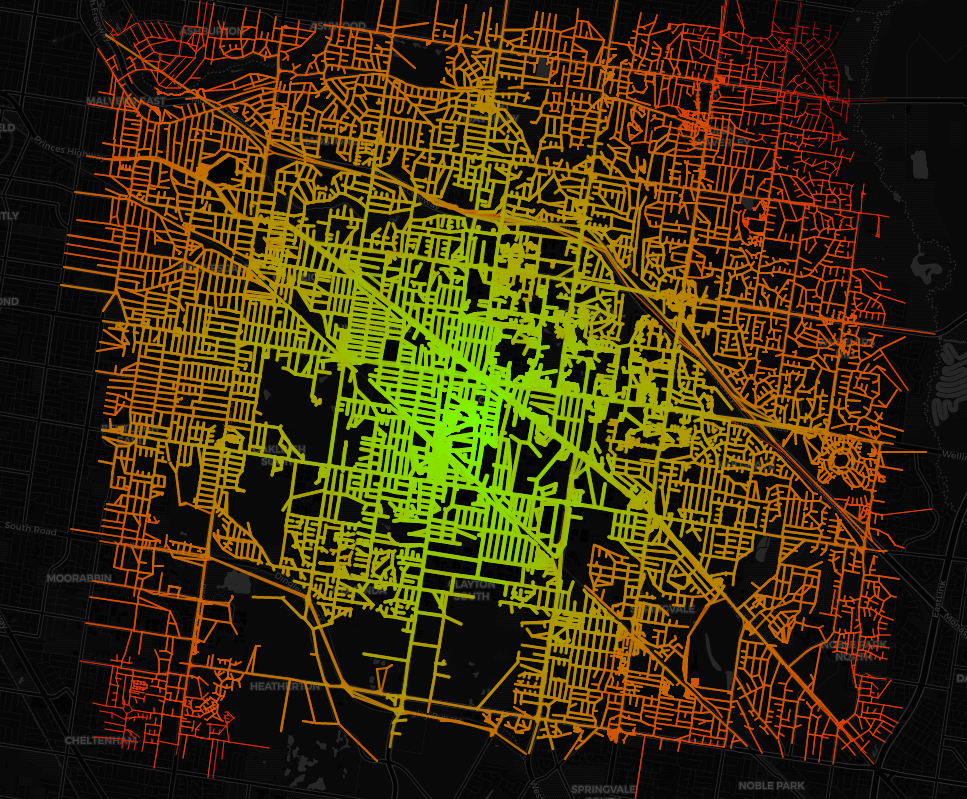

```r
library (mapview)
ncols <- 30
d <- graph_sf$dmmc / max (graph_sf$dmmc)
cols <- colorRampPalette (c ("lawngreen", "red")) (ncols) [ceiling (ncols * d)]
mapview (graph_sf, color = cols, lwd = 5 * (1 - d))
```

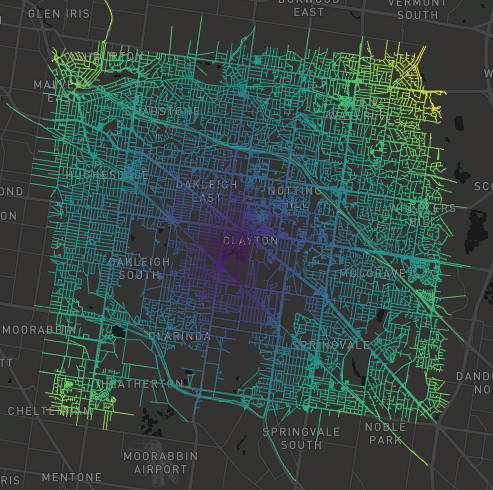

```r
library(mapdeck)
ncols <- 30
set_token(read.dcf("~/Documents/.googleAPI", fields = "MAPBOX"))
mapdeck(
  style = mapdeck_style("dark")
  , location = c(145.2, -37.95)
  , zoom = 11
    ) %>%
  add_path(
    data = graph_sf
    , stroke_colour = "dmmc"
  )
```